# Improve your plots with `ggplot2`

# The dataset

```r
# Install devtools
# install.packages("devtools")

# Install the package tvseries
# devtools::install_github("mireia-bioinfo/tvseries")
```

For this workshop wer are goint to use the dataset `tvseries_must_watch` from the `tvseries` R package. This dataset contins IMDb ratings for 4 TV series that I personally recommend you should watch! This TV series are: `c("Jane the Virgin", "Crazy Ex-Girlfriend", "Brooklyn Nine-Nine", "The Good Place")`.

**Warning!** Do not load the `tvseries` library as it will take a while (it has some big datasets). Just assign the `tvseries_must_watch` dataset to a new variable as shown below:

```r
# df <- tvseries::tvseries_must_watch
load("data/tvseries_must_watch.rda")
df <- tvseries_must_watch
df <- df[!is.na(df$average_rating),] # Remove rows with NA average rating
head(df)
```

|  | tvseries_title | episode_title | season_number | episode_number | start_year | end_year | runtime_min | genres | average_rating | num_votes |
| --- | --- | --- | --- | --- | --- | --- | --- | --- | --- | --- |
| 538753 | The Good Place | A Girl from Arizona, Part 2 | 4 | 2 | 2016 | NA | 22 | Comedy,Drama,Fantasy | 8.1 | 311 |
| 1675183 | Brooklyn Nine-Nine | Pilot | 1 | 1 | 2013 | NA | 23 | Comedy,Crime | 7.8 | 2938 |
| 1715236 | Brooklyn Nine-Nine | The Vulture | 1 | 5 | 2013 | NA | 22 | Comedy,Crime | 8.0 | 2069 |
| 1730051 | Brooklyn Nine-Nine | Halloween | 1 | 6 | 2013 | NA | 21 | Comedy,Crime | 8.5 | 2297 |
| 1730689 | Brooklyn Nine-Nine | The Tagger | 1 | 2 | 2013 | NA | 21 | Comedy,Crime | 7.6 | 2376 |
| 1731842 | Brooklyn Nine-Nine | 48 Hours | 1 | 7 | 2013 | NA | 21 | Comedy,Crime | 8.1 | 2044 |

Here you have some description of dataset columns:

| Name | Description |
| --- | --- |
| `tvseries_title` | Name of the TV series. |
| `episode_title` | Name of the episode. |
| `season_number` | Season number. |
| `episode_number` | Episode number. |
| `start_year` | Year the show started. |
| `end_year` | Year the show ended. |
| `runtime_min` | Length of the episode in minutes. |
| `genres` | Genres of the TV series. |
| `average_rating` | Average rating of the episode. |
| `num_votes` | Number of votes for that episode. |

# Using `ggplot2`

```r
install.packages("ggplot2", "scales", "palettetown", "ggsci")
```

```r
library(ggplot2)
```

## Basic `ggplot2`: Geometries

### **Example 1**: Plot the number of votes for each TV series using boxplots

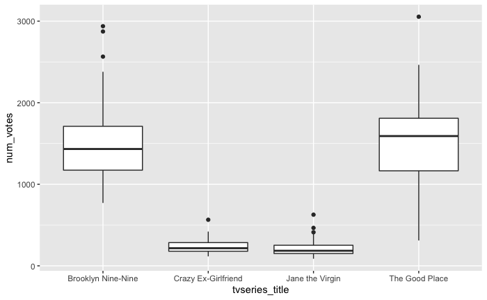

```r
ggplot(df,
       aes(tvseries_title, num_votes)) +
  geom_boxplot()
```

### **Example 2**: Plot the number of votes per season for each TV series using boxplots

[figure not shown]

```r
ggplot(df,
       aes(tvseries_title, num_votes,
           fill=season_number)) +
  geom_boxplot()
```

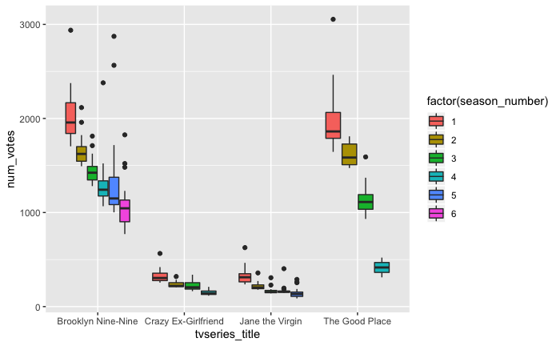

```r
ggplot(df,
       aes(tvseries_title, num_votes,
           fill=factor(season_number))) +
  geom_boxplot()
```

### **Exercise 1**: Plot the average ratings for each TV series using boxplots

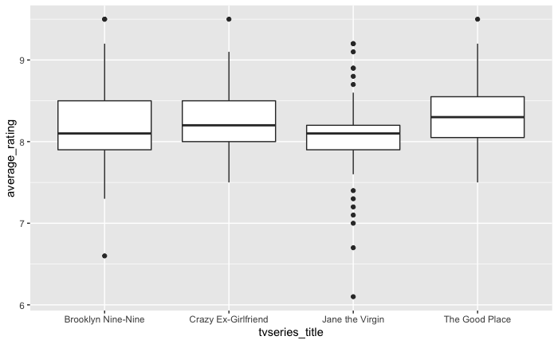

```r
ggplot(df,
       aes(tvseries_title, average_rating)) +
  geom_boxplot()
```

### **Exercise 2**: Plot the average ratings per season for each TV series using boxplots

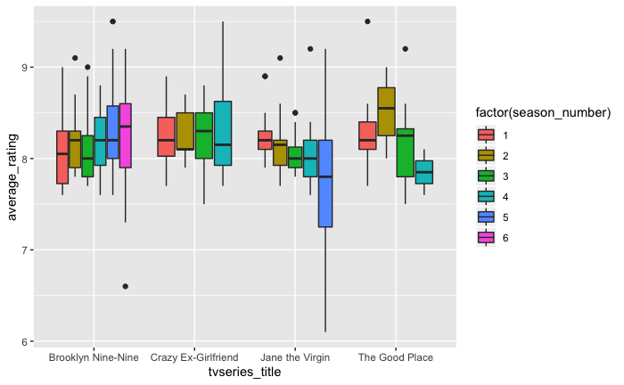

```r
ggplot(df,
       aes(tvseries_title, average_rating,
            fill=factor(season_number))) +
  geom_boxplot()
```

### **Exercise 3**: Plot the distribution of average ratings for each TV series using violin plots and boxplots

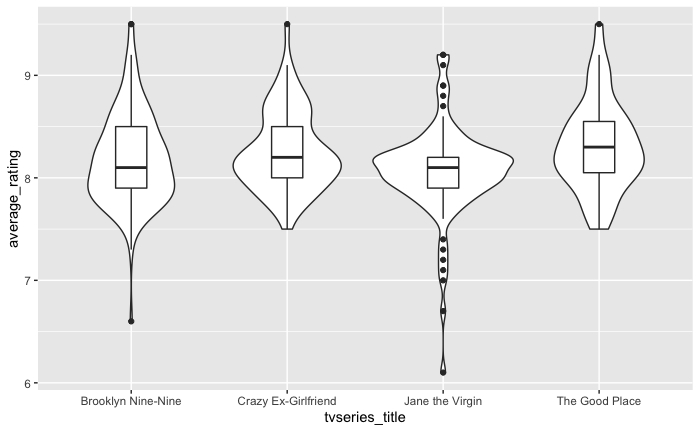

```r
ggplot(df,
       aes(tvseries_title, average_rating)) +
  geom_violin() +
  geom_boxplot(width=.2)
```

### **Example 3**: Plot the number of episodes for each TV series using barplots

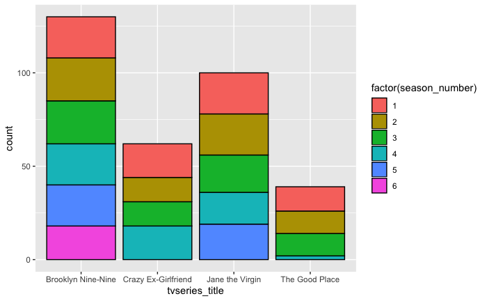

```r
ggplot(df,
       aes(tvseries_title,
           fill=factor(season_number))) +
  geom_bar(stat="count", color="black")
```

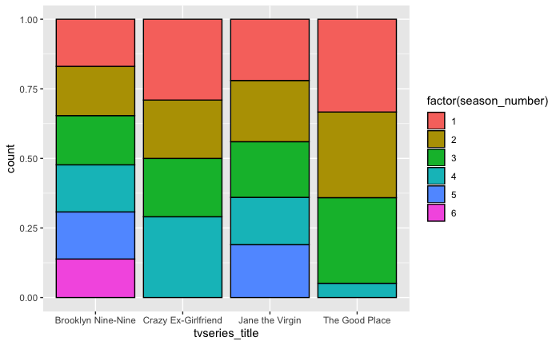

```r
ggplot(df,
       aes(tvseries_title,
           fill=factor(season_number))) +
  geom_bar(stat="count", color="black",
           position="fill")
```

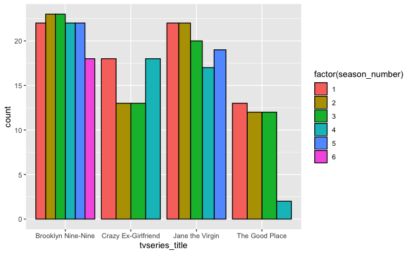

```r
ggplot(df,
       aes(tvseries_title,
           fill=factor(season_number))) +
  geom_bar(stat="count", color="black",
           position="dodge")
```

### **Exercise 4**: Plot the density of average ratings for each TV series.

**Tip**: `geom_density()` is another example of a function that does not need a y aesthetic. It automatically computes and draws the kernel density estimate

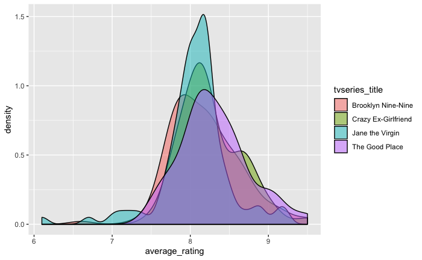

```r
ggplot(df,
       aes(average_rating)) +
  geom_density(aes(fill=tvseries_title),
                   alpha=0.5)
```

## Basic `ggplot2`: Scales

### **Example 4**: This plot looks quite sad and wrong… Let’s improve it by tweaking its scales!

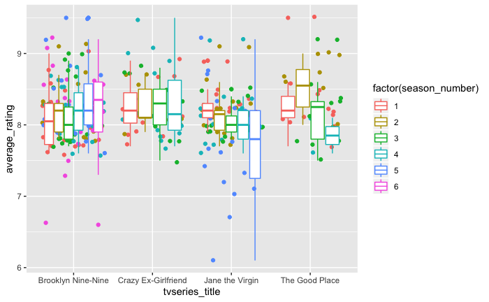

```r
ggplot(df,
       aes(tvseries_title, average_rating,
           color=factor(season_number))) +
  geom_jitter() +
  geom_boxplot()
```

- Labels for the axis and legend are terrible.
- Default `ggplot2` colors.
- Difficult to interpret… Many different boxplot and data points.

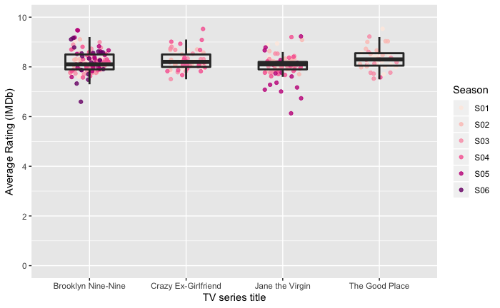

```r
ggplot(df,
       aes(tvseries_title, average_rating)) +
  geom_jitter(aes(color=factor(season_number)),
              width=0.2, alpha=0.8) +
  geom_boxplot(fill=NA, width=0.5, outlier.shape=NA,
               size=1) +
  scale_color_brewer(palette="RdPu",
                     name="Season",
                     labels=function(x) paste0("S0", x)) +
  scale_y_continuous(name="Average Rating (IMDb)",
                     breaks=scales::pretty_breaks(),
                     limits=c(0,10)) +
  xlab("TV series title")
```

### **Exercise 5**: Yet another sad plot… Try to improve it as much as you can!

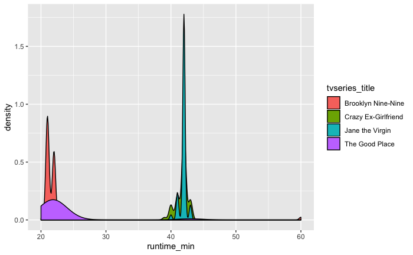

```r
ggplot(df,
       aes(runtime_min, fill=tvseries_title)) +
  geom_density()
```

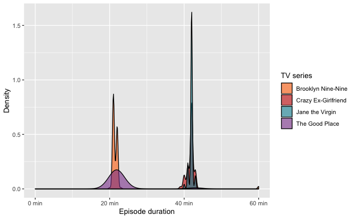

```r
ggplot(df,
       aes(runtime_min, fill=tvseries_title)) +
  geom_density(alpha=0.6) +
  ggsci::scale_fill_futurama(name="TV series") +
  scale_x_continuous(name="Episode duration",
                     breaks=scales::pretty_breaks(n=4),
                     labels=function(x) paste(x,
                                              "min"),
                     limits=c(0, NA)) +
  ylab("Density")
```

## Advanced `ggplot2`

### **Example 5**: Plot the mean average ratings per season for each TV series (`stat_summary()`).

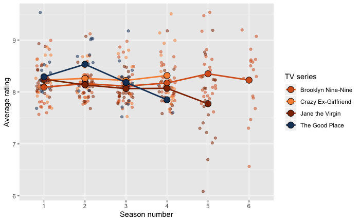

```r
ggplot(df,
       aes(factor(season_number), average_rating,
           color=tvseries_title,
           fill=tvseries_title)) +
  geom_jitter(width=0.2, alpha=0.5) +
  stat_summary(aes(group=tvseries_title),
               fun.y=mean, geom="line",
               size=1) +
  stat_summary(fun.y=mean, geom="point",
               size=4, pch=21, color="black") +
  palettetown::scale_color_poke(pokemon="charizard",
                                name="TV series") +
  palettetown::scale_fill_poke(pokemon="charizard",
                               name="TV series") +
  xlab("Season number") + ylab("Average rating")
```

**Tips**:

- `ggplot2` will try to collapse your legends: if you modify the colors or names, make sure they match if you want a single legend!
- When using `geom_line()` you will generally need to add a grouping for the variables. If not, you will get an error saying `geom_path: Each group consists of only one observation. Do you need to adjust the group aesthetic?`.

### **Example 6**: Zoom into an specific region of the plot (`coord_cartesian()`).

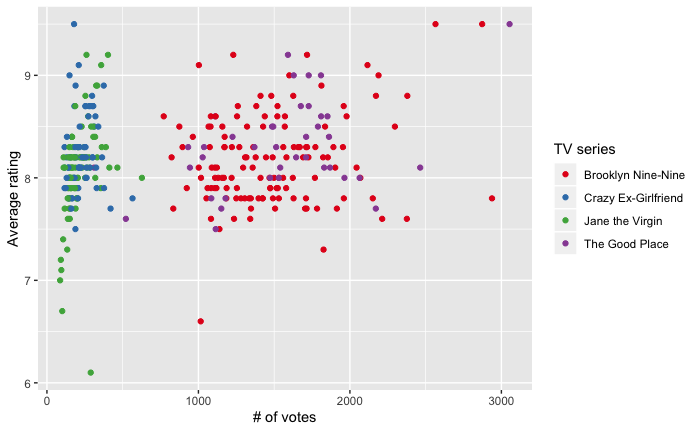

```r
ggplot(df,
       aes(num_votes, average_rating)) +
  geom_point(aes(color=tvseries_title)) +
  scale_color_brewer(palette="Set1",
                     name="TV series") +
  xlab("# of votes") + ylab("Average rating")
```

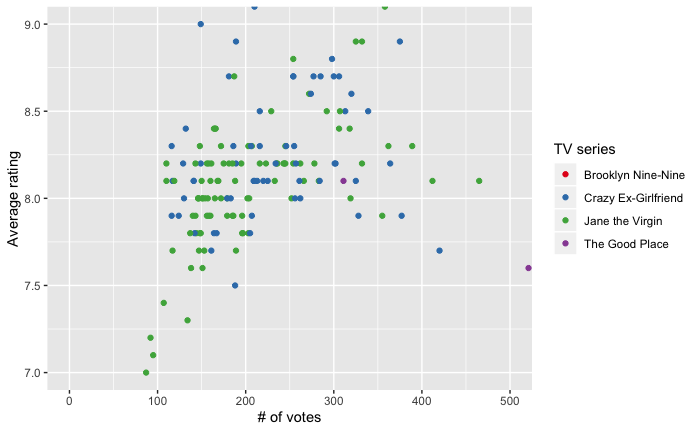

```r
ggplot(df,
       aes(num_votes, average_rating)) +
  geom_point(aes(color=tvseries_title)) +
  scale_color_brewer(palette="Set1",
                     name="TV series") +
  xlab("# of votes") + ylab("Average rating") +
  coord_cartesian(xlim=c(0,500), ylim=c(7,9))
```

### **Example 7**: Add classification according to the TV series title (`facet_wrap()`)

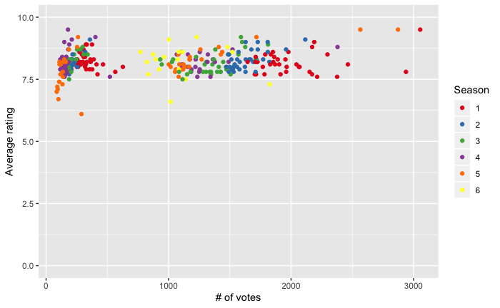

```r
ggplot(df,
       aes(num_votes, average_rating)) +
  geom_point(aes(color=factor(season_number))) +
  scale_color_brewer(palette="Set1",
                     name="Season") +
  xlab("# of votes") + ylab("Average rating") +
  ylim(0,10)
```

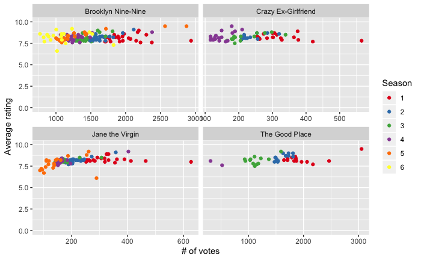

```r
ggplot(df,
       aes(num_votes, average_rating)) +
  geom_point(aes(color=factor(season_number))) +
  scale_color_brewer(palette="Set1",
                     name="Season") +
  xlab("# of votes") + ylab("Average rating") +
  ylim(0,10) +
  facet_wrap(~tvseries_title, scales="free_x")
```

### **Example 8**: Replace the default `ggplot2` theme for another one!

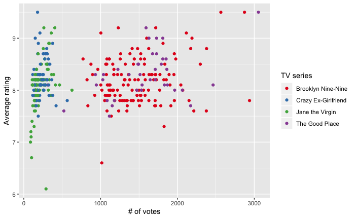

```r
ggplot(df,
       aes(num_votes, average_rating)) +
  geom_point(aes(color=tvseries_title)) +
  scale_color_brewer(palette="Set1",
                     name="TV series") +
  xlab("# of votes") + ylab("Average rating")
```

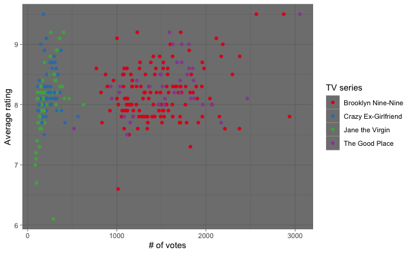

```r
ggplot(df,
       aes(num_votes, average_rating)) +
  geom_point(aes(color=tvseries_title)) +
  scale_color_brewer(palette="Set1",
                     name="TV series") +
  xlab("# of votes") + ylab("Average rating") +
  theme_dark()
```

### **Example 9**: Modify specific `theme()` elements so the plot looks nicer!

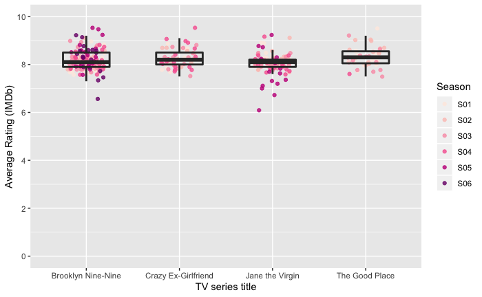

```r
ggplot(df,
       aes(tvseries_title, average_rating)) +
  geom_jitter(aes(color=factor(season_number)),
              width=0.2, alpha=0.8) +
  geom_boxplot(fill=NA, width=0.5, outlier.shape=NA,
               size=1) +
  scale_color_brewer(palette="RdPu",
                     name="Season",
                     labels=function(x) paste0("S0",
                                               x)) +
  scale_y_continuous(name="Average Rating (IMDb)",
                     breaks=scales::pretty_breaks(),
                     limits=c(0,10)) +
  xlab("TV series title")
```

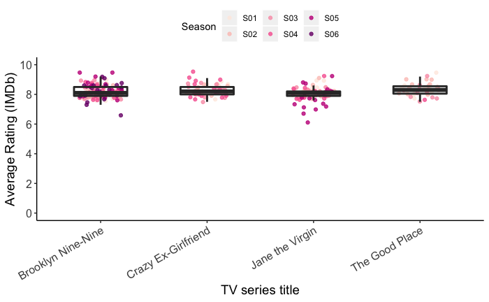

```r
ggplot(df,
       aes(tvseries_title, average_rating)) +
  geom_jitter(aes(color=factor(season_number)),
              width=0.2, alpha=0.8) +
  geom_boxplot(fill=NA, width=0.5, outlier.shape=NA,
               size=1) +
  scale_color_brewer(palette="RdPu",
                     name="Season",
                     labels=function(x) paste0("S0",
                                               x)) +
  scale_y_continuous(name="Average Rating (IMDb)",
                     breaks=scales::pretty_breaks(),
                     limits=c(0,10)) +
  xlab("TV series title") +
  theme(axis.text.x=element_text(angle=30, hjust=1),
        panel.background=element_rect(fill="white"),
        axis.line=element_line(size=0.5),
        legend.position="top",
        axis.text=element_text(size=12),
        axis.title=element_text(size=14))
```

# Expanding `ggplot2`

## Combined plots with `cowplot`

```r
# install.packages("cowplot")
library(cowplot)
```

## Animated plots with `gganimate`

```r
# install.packages("gganimate")
library(gganimate)
```

## Interactive plots with `ggiraph`

```r
# install.packages("ggiraph")
library(ggiraph)
```